# Projeto Integrador

Bioengenharia de Solos

Prof. Dr. Luiz Diego Vidal Santos

## Abertura Visão Geral da Aula

Roteiro da aula Tópicos estruturantes

- 1 Integração de técnicas: visão sistêmica
- 2 Diagnóstico geotécnico e ambiental
- 3 Árvore de decisão: seleção de técnicas
- 4 Combinação de técnicas por zonas
- 5 Cronograma e orçamento
- 6 Memorial descritivo e peças gráficas
- 7 Apresentação do cenário final
- 8 Briefing e início do projeto

Objetivo da aula Plano de Estabilização de Talude Complexo

Aplicar o repertório completo de **bioengenharia de solos** a um caso complexo, integrando diagnóstico geotécnico, seleção fundamentada de técnicas, cronograma de execução, estimativa orçamentária e memorial técnico — simulando a atuação profissional de consultoria ambiental e geotécnica.

Aulas 01–20 Integradas Memorial · Plantas · Pitch Caso Rio Subaé (BA)

# Integração de Técnicas: Visão Sistêmica

## Repertório Repertório Completo e Analogia Sistêmica

Revestimento Aulas 13–14

Hidrossemeadura e biomantas antierosivas na superfície exposta.

Contenção Aulas 15, 17, 18

Enrocamento vegetado, gabião vivo e Parede Krainer na base.

Escoamento & Fluvial Aulas 10–12, 16, 19–20

Paliçadas, barraginhas, cordões, feixes vivos, defletores, *brushlayering* e canaleta verde.

| Zona do talude | Técnica | Analogia |
| --- | --- | --- |
| Base (pé) | Gabião vivo / Enrocamento | Fundação — “esqueleto” |
| Corpo | Cordões + Feixes | Musculatura — “contenção” |
| Superfície | Biomanta + Hidrossemeadura | Pele — “proteção” |
| Drenagem | Espinha de peixe | Sistema circulatório |

**Nenhuma técnica isolada** resolve uma encosta complexa: a solução eficaz articula **base** (contenção), **corpo** (controle de escoamento), **superfície** (revestimento) e **drenagem** contínua.

# Diagnóstico Geotécnico e Ambiental

## Mecanismos Reconhecer os Processos para Integrar as Técnicas

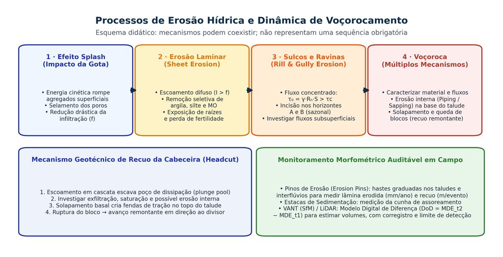

Diagrama didático de mecanismos erosivos e evolução de voçoroca por piping.

Evolução de Processos Erosivos Profundos e Monitoramento O esquema apoia a formulação de hipóteses; o projeto executivo exige evidências de campo, geometria, água no solo e ensaios

Diagnóstico rigoroso evita tratar apenas o sintoma superficial quando há **solapamento basal**, **piping** ou **escoamento concentrado** a montante.

## Levantamentos Etapa de Diagnóstico e Checklist de Campo

1 · Geotécnico Solo e água

Sondagem a trado/SPT, granulometria, Atterberg, cisalhamento direto ($\gamma, \phi, c, k$) e piezometria (N.A.).

2 · Topográfico Geometria

Levantamento planialtimétrico (drone RTK / estação total), MDT, declividades e perfis transversais.

3 · Hidrológico Chuva e vazão

Precipitação (ANA, INMET), tempo de concentração, $TR = 10, 25, 50$ anos e SCS-CN.

4 · Ambiental Meio físico e legal

Cobertura vegetal, processos erosivos ativos, **APP / APA / UC** e fauna/flora sensíveis.

**Fluxo:** Reconhecimento → Topobatimetria → Geotecnia → Hidrologia → Ambiental → **Relatório de Diagnóstico** → Seleção das técnicas.

| Checklist de campo | Verificado |
| --- | --- |
| Fotos panorâmicas + detalhes / Acesso máquinas | ☐ |
| Declividade (clinômetro) + amostras de solo | ☐ |
| Processos erosivos + N.A. (poço/nascente) | ☐ |
| Vegetação existente (%) + infraestrutura no entorno | ☐ |

# Árvore de Decisão: Seleção de Técnicas

## Fluxograma Árvore de Decisão para Seleção de Técnicas

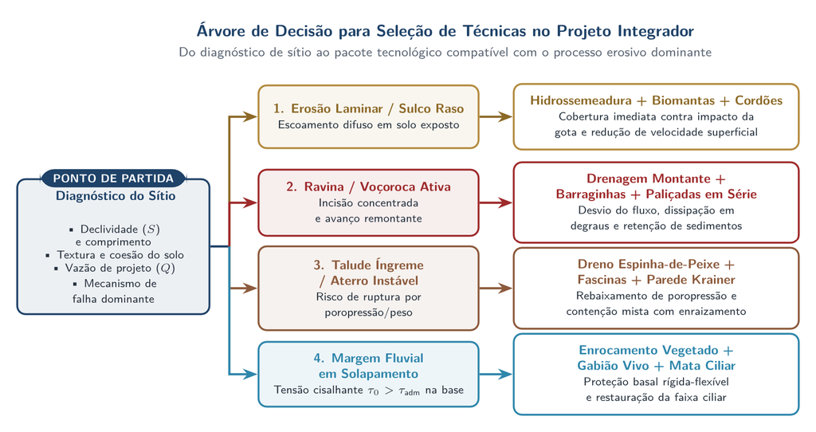

Árvore de decisão do diagnóstico de sítio ao pacote tecnológico compatível com o processo erosivo dominante.

Árvore de Decisão: Do Diagnóstico de Sítio ao Pacote Tecnológico Seleção integrada conforme tipo de erosão (laminar, ravina/voçoroca, talude íngreme ou margem fluvial)

**Regra prática:** comece pela **base** (contenção), suba pelo **corpo** (controle de escoamento) e finalize na **superfície** (revestimento), com **drenagem** em todas as zonas.

## Critérios Matriz de Seleção por Processo Erosivo

Erosão superficial Laminar vs. Sulcos

- **Laminar:** Biomanta + Hidrossemeadura
- **Em sulcos:** Cordões vegetativos + Hidrossemeadura

Erosão em ravinas Rasa vs. Profunda

- **Rasa:** Paliçadas + Feixes vivos
- **Profunda:** Gabião vivo + Paliçadas

Instabilidade de encosta Declividade < ou > 45°

- **< 45°:** Cordões + Feixes + Biomanta
- **> 45°:** Parede Krainer ou Gabião vivo

Margem fluvial Baixa vs. Alta

- **Baixa:** Enrocamento vegetado + *Brushlayering*
- **Alta:** Gabião vivo + Defletores

| Fator de decisão | Peso |
| --- | --- |
| Declividade | ★★★★★ |
| Tipo de erosão | ★★★★★ |
| Exigência ambiental (APP) | ★★★★★ |
| Tipo de solo / Orçamento / Urgência | ★★★★☆ |
| Disponibilidade de materiais / Acesso | ★★★☆☆ |

# Combinação de Técnicas por Zonas

## Zoneamento Zoneamento Integrado de Intervenções na Vertente

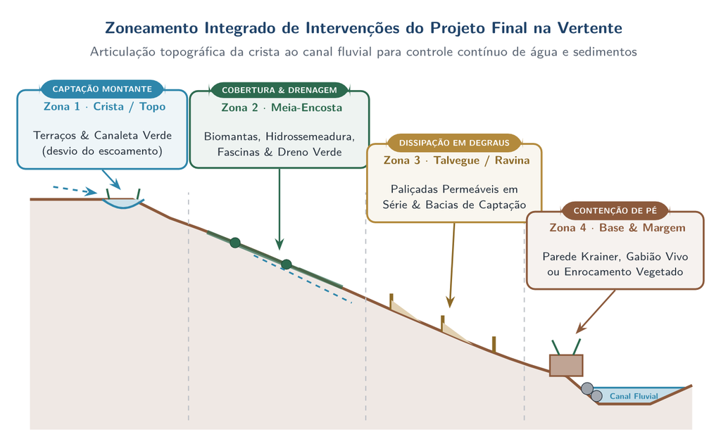

Zoneamento topográfico integrado da crista ao canal fluvial para controle contínuo de água e sedimentos.

Zoneamento Topográfico Integrado: Da Crista / Topo ao Canal Fluvial Zona 1 (Crista) → Zona 2 (Meia-Encosta) → Zona 3 (Talvegue / Ravina) → Zona 4 (Base & Margem)

**Sempre comece pela drenagem e pela base:** estabilizar o pé do talude é a ação mais urgente; sem base firme, qualquer intervenção no corpo será comprometida.

## Prioridade Tabela de Combinação e Ordem Executiva

| Zona do perfil | Técnica primária | Técnica complementar |
| --- | --- | --- |
| **A · Crista** | Hidrossemeadura | Biomanta, canaleta de crista |
| **B · Corpo superior** | Cordões vegetativos | Biomanta entre cordões |
| **C · Corpo inferior** | Feixes vivos (espinha de peixe) | Paliçadas (se houver ravinas) |
| **D · Pé / Base** | Gabião vivo ou Parede Krainer | Enrocamento na fundação |
| **E · Margem / Canal** | Enrocamento vegetado | Defletores, *brushlayering* |

1ª · Drenagem Desvio montante

Interceptar enxurrada antes de atingir o talude.

2ª · Base / Pé Fundação segura

Executar gabião, Krainer ou enrocamento de pé.

3ª · Corpo Dissipação

Instalar paliçadas, cordões e drenos feixes vivos.

4ª–5ª · Pele & APP Cobertura final

Biomanta, hidrossemeadura e restauração da mata ciliar.

# Cronograma e Orçamento

## Planejamento Cronograma de Execução e Modelo Orçamentário

| Mês | Atividade de implantação |
| --- | --- |
| 1 | Diagnóstico, projeto e mobilização |
| 2 | Drenagem superficial + escavação fundação |
| 3 | Gabião vivo / Krainer (base) |
| 4 | Cordões vegetativos + feixes vivos (corpo) |
| 5 | Hidrossemeadura + biomanta (superfície) |
| 6 | Plantio complementar + mata ciliar |
| 7–12 / 13–24 | Monitoramento mensal (1º sem.) / bimestral |

Fatores críticos de prazo Sazonalidade e logística

**Estação seca:** obras estruturais · **Estação chuvosa:** plantio de espécies vivas · **Acesso** e **licenciamento** ambiental.

| Item de orçamento | Unid. | Custo típico (R$) |
| --- | --- | --- |
| Hidrossemeadura / Biomanta de coco | m² | 8–15 / 12–25 |
| Enrocamento vegetado / Parede Krainer | m³ | 150–350 / 200–500 |
| Cordão vegetativo / Feixes vivos / Paliçada | m | 30–60 / 50–100 / 20–50 |
| Gabião vivo (1×1×2 m) / Defletores tronco | un. | 800–1.500 / 500–2.000 |
| Mata ciliar (muda + plantio) | un. | 15–30 |

A bioengenharia custa tipicamente **30–60%** de uma obra convencional equivalente em concreto e gera externalidades valoráveis em **carbono e PSA**.

# Memorial Descritivo e Peças Gráficas

## Relatório Técnico Estrutura do Memorial, Peças Gráficas e Softwares

Sumário modelo do projeto 8 seções obrigatórias do Memorial

1. **Introdução e objetivos** (localização, problema, meta)
2. **Diagnóstico** (geotécnico, hidrológico, ambiental)
3. **Seleção de técnicas** (árvore de decisão, zoneamento)
4. **Projeto executivo** (memorial de cálculo, especificações, peças gráficas)
5. **Cronograma de execução**
6. **Estimativa orçamentária**
7. **Plano de monitoramento**
8. **Referências e anexos**

| Peça gráfica obrigatória | Conteúdo principal |
| --- | --- |
| Situação / Intervenção | Acessos, entorno e zoneamento |
| Perfis / Detalhe construtivo | Seções e detalhes (gabião, Krainer, cordão) |
| Plantio / Drenagem | Espécies, espaçamentos, canaletas e drenos |

| Software recomendado | Aplicação |
| --- | --- |
| QGIS / ArcGIS · AutoCAD / Civil 3D | MDT, mapas, plantas e perfis |
| HEC-RAS / Iber · GeoStudio (SLOPE/W) | Hidráulica e estabilidade de taludes |
| Excel / R / Python | Cálculos e gráficos |

# Cenário do Projeto Integrador

## Caso Complexo Estudo de Caso: Encosta Adjacente ao Rio Subaé

| Parâmetro (Feira de Santana – BA) | Valor |
| --- | --- |
| Comprimento / Altura total | 80 m / 15 m |
| Declividade média | 35° (porções > 50°) |
| Solo | Argilo-siltoso laterítico |
| Parâmetros ($\gamma$, $\phi$, $c$) | $17{,}5 \text{ kN m}^{-3}$ · $24°$ · $8 \text{ kPa}$ |
| Nível d’água (N.A.) / Precipitação | 3 m de profundidade / 850 mm/ano |
| Uso atual / Legislação | Pastagem degradada + ravinas / **APP 30 m** |
| Rio Subaé na base | Largura 12 m · $V_{cheia} = 2{,}2 \text{ m/s}$ |

Problemas identificados Condições críticas e favoráveis

- 🔴 **2 ravinas** ativas (prof. 1,5 m) + **desbarrancamento** na margem
- 🟡 **Erosão laminar** severa (terço sup.), **70% solo exposto**, **APP** sem mata ciliar
- 🟢 Acesso pelo topo, eucalipto regional e espécies de estaquia disponíveis

**Perfil esquemático:** Crista (estrada) → Zona Sup. (laminar/exposto) → Zona Média (2 ravinas, > 45°) → Zona Inf. (35°) → Base (desbarrancamento) → **Rio Subaé (12 m)**.

# Briefing e Início do Projeto

## Orientações Entregáveis, Critérios de Avaliação e Prazos

1 · Memorial (PDF) 15–25 páginas

Diagnóstico, árvore de decisão, zoneamento, memorial de cálculo (empuxo, FS), materiais, Gantt, orçamento e monitoramento (2 anos).

2 · Peças gráficas A3 ou A2 (DWG/QGIS)

Planta de intervenção com zoneamento, **2 perfis transversais** com detalhes e **1 detalhe construtivo** ampliado.

3 · Defesa oral 15 minutos

Pitch estilo consultoria técnica e defesa do projeto perante a banca.

| Critério de avaliação | Peso |
| --- | --- |
| Diagnóstico e fundamentação | 15% |
| Seleção e combinação de técnicas | 20% |
| Memorial de cálculo | 20% |
| Peças gráficas | 15% |
| Cronograma, orçamento, monitoramento e oral | 10% + 10% + 10% |

| Sem. | Etapa (Grupos 3–5 · Entrega 1 sem. antes) |
| --- | --- |
| 1–2 | Grupos + diagnóstico → Técnicas + zoneamento |
| 3–4 | Cálculos + especificações → Peças + memorial |
| 5 | **Apresentação final** |

## Dicas e Síntese O Que a Banca Valoriza e Síntese do Curso

6 pilares de qualidade O que a banca valoriza

1. **Coerência** com dados · **2. Integração** em sistema (não lista) · **3. Fundamentação** (normas/fórmulas) · **4. Viabilidade** (prazo/custo) · **5. Sustentabilidade** (materiais/nativas) · **6. Monitoramento** com indicadores claros.

| Erro comum | Como evitar |
| --- | --- |
| Técnica isolada / Sem cálculos | Integrar por zonas + memorial mínimo |
| Espécies não regionais | Consultar flora Caatinga / Cerrado |
| Cronograma sem chuva / Orçamento irreal | Plantar março–junho · Referência SINAPI |

**Aulas 1–9:** Solo, erosão, topografia, terraços, canais e modelagem 3D.

**Aulas 10–14:** Paliçadas, barraginhas, feixes vivos, hidrossemeadura e biomantas.

**Aulas 15–18:** Enrocamento, cordões vegetativos, gabião vivo e Parede Krainer.

**Aulas 19–21:** Bioengenharia fluvial, canaleta verde e **Projeto Integrador**.

Este projeto é a **síntese do curso**: apliquem tudo dos fundamentos (Aulas 01–04) à bioengenharia fluvial e canaleta verde (Aulas 19–20). **Bom trabalho!**

## Referências Referências Gerais do Curso

Normas e literatura fundamental Padronização e geotécnica

- ABNT. Normas NBR 7190, NBR 10514, NBR 16757. Associação Brasileira de Normas Técnicas.
- DNIT (2006). Normas 071/2006-ES (Revegetação) e 082/2006-ES (Gabiões). DNIT.
- Florineth, F. (2004). *Pflanzen statt Beton*. Patzer Verlag.
- Gray, D. H. & Sotir, R. B. (1996). *Biotechnical and Soil Bioengineering Slope Stabilization*. Wiley.
- Morgan, R. P. C. & Rickson, R. J. (1995). *Slope Stabilization and Erosion Control*. Spon.

Bioengenharia contemporânea Referências científicas e manuais

- Norris, J. E. et al. (2008). *Slope Stability and Erosion Control: Ecotechnological Solutions*. Springer.
- Rey, F. et al. (2019). Soil and water bioengineering. *Science Total Env.*, 648, 1210-1218.
- Schiechtl, H. M. & Stern, R. (1996). *Ground Bioengineering Techniques*. Blackwell Science.
- Stokes, A. et al. (2014). Ecological mitigation of hillslope instability. *Plant Soil*, 377, 1-23.
- Zeh, H. (2007). *Soil Bioengineering Construction Type Manual*. EFIB/vdf.

Obrigado!

**Prof. Luiz Diego Vidal Santos**

📧 luiz.diego@uefs.br

🌐 ldvsantos.github.io/cv